# Spatial Transcriptomics with Visium

Analysing sections of the developing human heart

Raphaël Mauron

V4SDB Student Summer School · 2 September 2026

# Welcome

## Today

You are going to analyse spatial transcriptomics data from a **human embryonic heart**.

- All the code is written for you
- Your job is to read it, run it, and understand *why* each step exists
- The biology is yours — you know hearts better than the code does

**Note**

Everything we do today is a simplified version of a real, published pipeline.

## Plan for the session

**Wednesday 2 September 2026 · 09:00 – 13:00**

| Time | Topic |  |
| --- | --- | --- |
| 09:00 | Introduction, setup, first look at the tissue |  |
| 09:30 | Filtering and quality control | one section |
| 10:15 | Normalization, scaling, variable genes |  |
| **10:40** | **Break** |  |
| 10:55 | PCA, clustering, mapping clusters onto anatomy |  |
| 11:35 | Cluster markers, comparison with the published atlas |  |
| 12:10 | Three sections together, batch correction | three sections |
| 12:45 | Temporal changes, spatial statistics, wrap-up |  |
| 13:00 | End |  |

Parts 10 and 11 are written so you can finish them on your own.

## Two rules for the day

1. **Ask immediately.** If a chunk errors, do not silently fall behind — we fix it together.
2. **Run in order, top to bottom.** Several steps overwrite objects. Jumping around produces errors that look mysterious but are not.

Red text in the console is often just a warning. Not everything red is broken.

# Part 0 · What is Visium?

## The problem

**Bulk RNA-seq** — *what* genes, but not *where*. **Single-cell RNA-seq** — *what* genes in *which* cell, but the tissue is dissociated and position is destroyed.

**Spatial transcriptomics** — keep the tissue intact, and record where each transcript came from. A poly-T oligo binds the poly-A tail *in situ*; the barcode underneath records the position.

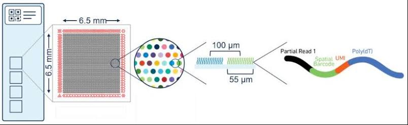

## How the array works

A glass slide carries a grid of spots:

- **~5,000 spots** per capture area
- **55 µm** diameter · **100 µm** centre-to-centre

Every spot carries millions of capture oligos sharing a **spatial barcode** unique to that position.

Section onto the slide → permeabilise → mRNA diffuses down → poly-T captures poly-A → sequence.

The barcode says *where*. The read says *which gene*.

## Two consequences that shape everything

**1. A spot is a position, not a cell.** At 55 µm it covers a handful of cells. Every measurement is a local *mixture*.

**2. Poly-A capture is indiscriminate.** Anything polyadenylated gets sequenced, whether or not you wanted it.

A large part of today is **deciding what to keep**.

## Where the data comes from

> Lázár, Mauron, Andrusivová et al.  
> *Spatiotemporal gene expression and cellular dynamics of the developing human heart.*  
> **Nature Genetics** 57, 2756–2771 (2025)

**The full study**

- 16 hearts · 38 Visium sections
- 69,114 spots · PCW 6–12
- scRNA-seq: 76,991 cells
- ISS: 150 transcripts

**Today**

- 3 sections
- PCW 6, 9, 10
- ~2,200 spots for part 1

Interactive atlas → https://hdcaheart.serve.scilifelab.se

Tissue donated after elective medical abortion with written informed consent, Swedish ethical permit 2018/769-31.

# Part 1 · One section

## What Space Ranger gives us

| File | What it is |
| --- | --- |
| `filtered_feature_bc_matrix.h5` | the counts — genes × spots |
| `tissue_hires_image.png` | the H&E image |
| `tissue_positions_list.csv` | which pixel each barcode sits on |
| `scalefactors_json.json` | how to scale image to spots |

```r
object <- ReadVisiumData(infoTable)
object <- LoadImages(object)
object
```

```
An object of class Seurat
36601 features across 2234 samples within 1 assay
Active assay: Spatial (36601 features, 0 variable features)
 1 layer present: counts
```

How many features? how many spots? which assay? which layers exist *so far*?

## Before anything else: look at the tissue

At PCW 10 you should find the **compact** and **trabeculated myocardium**, the **atrial wall**, the **interventricular septum**, the **valve region**, the **chamber lumens** and the **epicardium**.

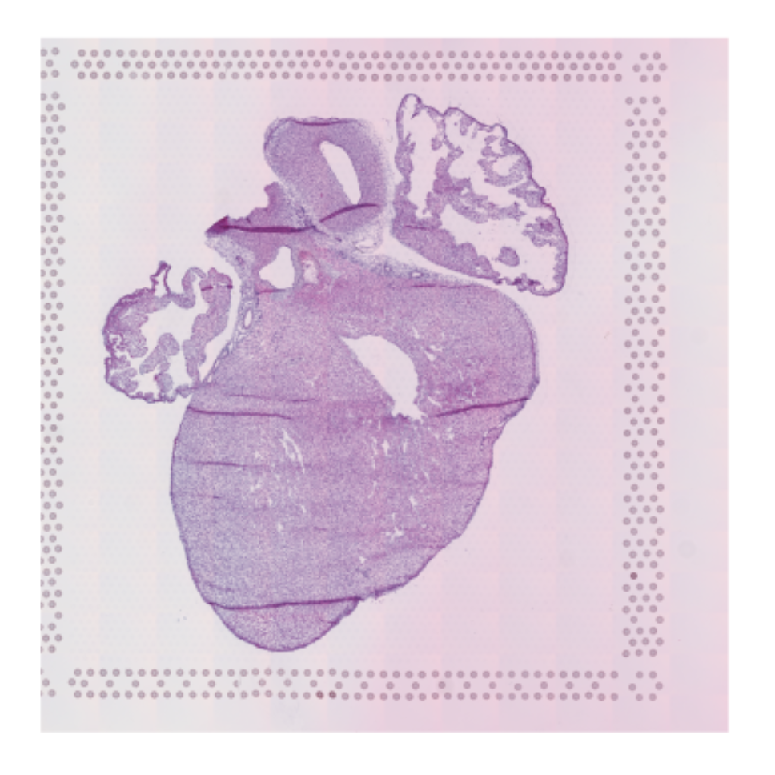

**Important**

Every plot today puts coloured dots on this image. They only mean something if you know what is underneath.

## First orientation: MYH6 vs MYH7

Atrial and ventricular myosin heavy chains — they should split the section in two.

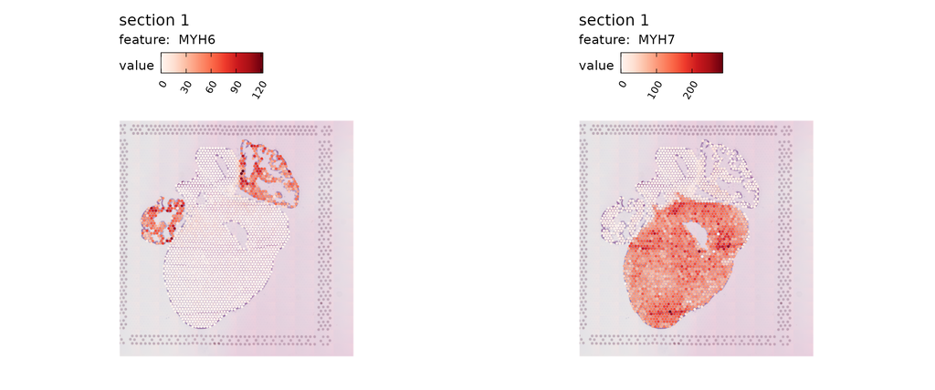

Does the split match where you expected atria and ventricles? Find a region where neither is expressed — what is there instead?

## We have ~36,000 genes. Humans have ~19,000.

Four families dominate the counts and vary for reasons unrelated to anatomy:

- **Hemoglobin** — the heart is full of blood
- **Mitochondrial** — 13 genes; tracks muscle density *and* RNA degradation
- **Ribosomal proteins** — ~85 genes, move as a block, 10–25% of counts
- **MALAT1** — nuclear lncRNA; reads out permeabilisation more than biology

Together, about **a third of all counts** in this dataset.

## The pattern we actually use

```r
pattern <- paste0(
  "^MT-",                      # 13 mitochondrial genes
  "|^HB[ABDEGMQZ][0-9]?$",     # HBA1/2, HBB, HBD, HBE1, HBG1/2, HBM, HBQ1, HBZ
  "|^RP[LS][0-9]+[A-Z]?[0-9]?$|^RPL36AL$|^RPLP[0-9]$|^RPSA$",
  "|^MALAT1$"
)
undesirable_genes <- setdiff(grep(pattern, rownames(object), value = TRUE), "RPL3L")
length(undesirable_genes); head(undesirable_genes, 18)
```

```
[1] 110
```

```
 [1] "RPL22"   "RPL11"   "RPS8"    "RPL5"    "RPS27"   "RPS7"    "RPS27A"
 [8] "RPL31"   "RPL37A"  "RPL32"   "RPL15"   "RPSA"    "RPL14"   "RPL29"
[15] "RPL24"   "RPL22L1" "RPL39L"  "RPL35A"
```

Those `$` anchors are load-bearing — a looser pattern silently swallowed **eleven RPS6K kinases**. Always check the other direction too.

## Second filter: keep protein-coding only

Annotate the remainder against the GRCh38-2020-A reference and keep `protein_coding`. Project-dependent — studying immunoglobulin loci or lncRNAs? Different call.

**A trap**

Subsetting genes does **not** update the metadata. Recompute it, or your QC describes a matrix you no longer have.

```r
object <- SubsetSTData(object, features = genes_to_keep_2)

object$nCount_Spatial   <- colSums(LayerData(object, "counts"))
object$nFeature_Spatial <- colSums(LayerData(object, "counts") > 0)

all(object$nCount_Spatial == colSums(LayerData(object, "counts")))  # must be TRUE
```

## Quality control — but for spatial

In single-cell, low counts means a dying cell — filter it. In Visium a spot is a **fixed position**, so low counts usually means **low cellularity**: a lumen, cardiac jelly, a section edge.

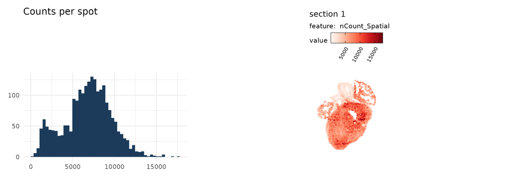

**Tip**

So we keep every spot — the low-count regions **are** anatomy.

## Normalization and scaling — different axes

### `NormalizeData()` · per **spot**

`log1p(count / total × 10000)`

### `ScaleData()` · per **gene**

`(x − µ) / σ` — a z-score

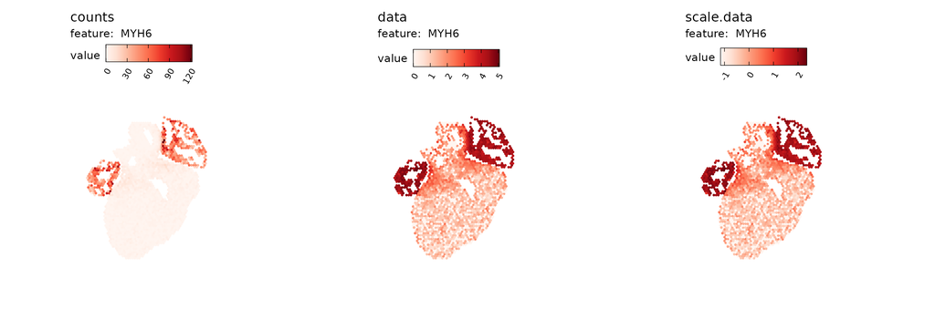

Same gene, three layers. Scaling is applied to the *normalized* values.

## Variable features

3,000 genes instead of 19,000 — better signal-to-noise, much faster.

`vst` fits `log(variance)` against `log(mean)` by loess, then standardises each gene against its **expected** variance:

$$z_{ij}=\frac{x_{ij}-\bar{x}_i}{\sigma_i^{\text{exp}}}$$

Genes are ranked by the variance of those standardised values.

High variance **≠** spatially organised. We return to this at the very end.

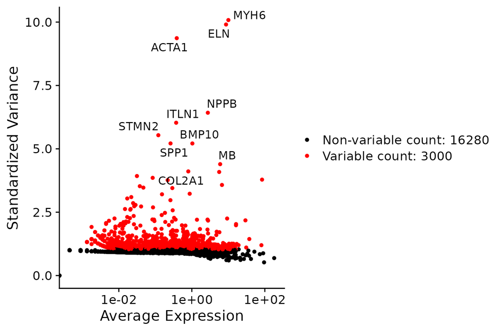

## Clustering, in five steps

**PCA** — 3,000 genes condensed into a few dozen “master trends”

**Neighbours** — build a shared-nearest-neighbour graph

**Clusters** — Louvain community detection on that graph

**UMAP** — a 2D picture of that graph

**Map it back onto the tissue** ← the important one

## The UMAP is not the result

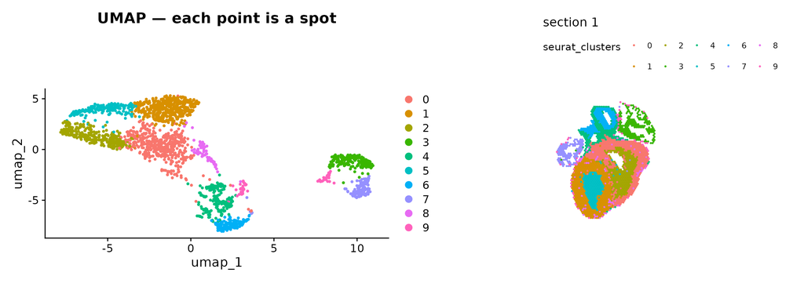

**Important**

A cluster tracing a recognisable structure is believable. A cluster scattered across unrelated regions is usually a technical gradient.

## Cluster markers

`FindAllMarkers()` — Wilcoxon test, each cluster against all others.

```r
detable <- FindAllMarkers(object, only.pos = TRUE,
                          max.cells.per.ident = 300, ...)
```

We add `pct.diff` = `pct.1 − pct.2`: how *specific* a gene is to its cluster.

**Do you recognise any genes?**

**Why does MYH6 appear in several clusters at once?**

## Comparing with the published atlas

**Us**

- 1 section · ~2,200 spots
- default parameters
- 20 minutes

**The atlas**

Not a fair fight — and that is the point. **What can a quick analysis recover, and what does it miss?**

## Why we will not find 23 clusters

**Power** — the SA node is a handful of spots. No resolution will find it.

**Sampling** — whether a structure appears depends on the cutting plane.

**Parameters** — we picked `resolution = 1` and 20 PCs without looking at alternatives.

Coarse is not wrong. Knowing *which* results survive these choices is most of the skill.

# Part 2 · Three sections

## Why more than one section?

- Is your cluster reproducible, or a one-slide artefact?
- Does a structure change between PCW 6 and PCW 10?
- n = 1 tells you nothing about variability

**Before we look**

What should look the **same** across ages? What should differ **biologically**? What might differ for purely **technical** reasons?

## Can we recover the sex from the data?

Mean raw counts per section, next to the reported metadata:

| sample_id | pcw_age | sex | XIST | DDX3Y |
| --- | --- | --- | --- | --- |
| V10A13-160_A1 | 6 | male | 0.00 | 1.81 |
| V10A13-157_C1 | 9 | female | 1.97 | 0.00 |
| V10F24-105_C1 | 10 | male | 0.00 | 0.48 |

Must be done **before** filtering — XIST is a lncRNA, and RPS4Y1 looks ribosomal to our regex.

[figure not shown]

## Batch effect

Three sections, three slides, three capture events. Some of what separates them is **technical**.

**Harmony** adjusts the PCA embedding so spots group by biology rather than by slide.

```r
se <- RunHarmony(se, group.by.vars = "sample_id")
```

We cluster **both ways** and compare. If clusters split perfectly by `sample_id`, that split was batch.

## The diagnostic: colour by section, not by cluster

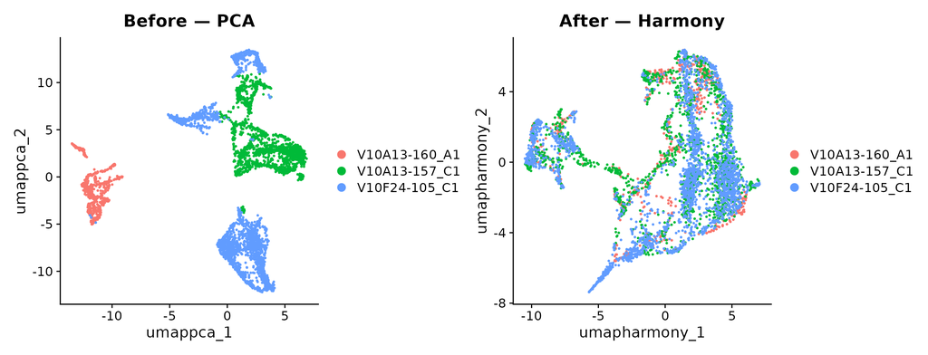

Separate territories → the dominant signal is *which slide the spot came from*. Overlapping → spots sit together when transcriptionally similar.

## But: our design is confounded

One section per age, so `sample_id` and `pcw_age` carry **identical** information.

```
                   6    9   10
  V10A13-160_A1  615    0    0
  V10A13-157_C1    0 1545    0
  V10F24-105_C1    0    0 2234
```

Telling Harmony to remove differences between sections also tells it to remove differences between **developmental stages**. It cannot tell them apart.

**With at least 2 sections per heart they stop being the same variable.** You could correct on `sample_id` while `pcw_age` still varies *within* each corrected group — the slide effect goes, the age signal survives. Exactly why the atlas took near-consecutive replicate sections from all 16 hearts.

## Over- and under-correction

**Over-correct**

You erase real differences between samples

**Under-correct**

Technical signal drives your clusters

There is no setting correct in general. There is a setting appropriate to **your question**, and you have to be able to defend it.

# Part 3 · Going further

## Does anything change with age?

Take **one cluster**, split it by age. Every spot comes from the same cluster, so the comparison is about **age**, not cluster identity. Genes ranked by `pct.diff`, not fold-change — specificity, not loudness.

| age | gene | avg_log2FC | pct.diff |
| --- | --- | --- | --- |
| 6 | KRT19 | 4.69 | 0.90 |
| 6 | HMGA2 | 2.67 | 0.73 |
| 6 | CLDN6 | 2.46 | 0.71 |
| 9 | AHSP | 2.96 | 0.51 |
| 9 | HSPA1B | 2.94 | 0.50 |
| 9 | ALAS2 | 3.15 | 0.48 |
| 10 | EIF1AY | 2.23 | 0.48 |
| 10 | TMEM176B | 3.31 | 0.47 |
| 10 | TMEM176A | 3.43 | 0.36 |

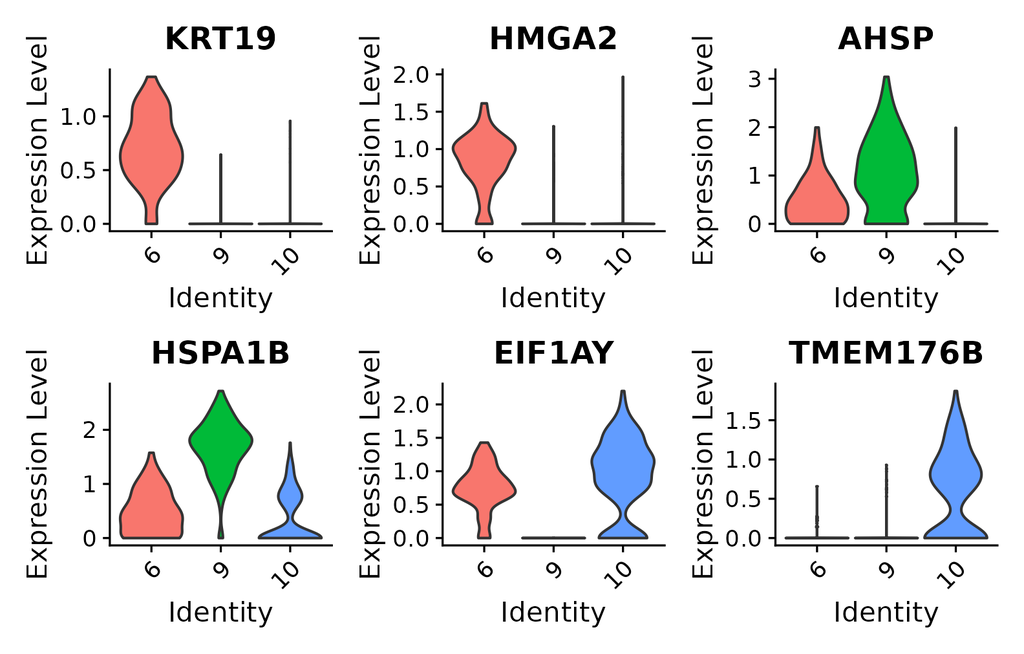

Each age is tested against the **other two pooled** — and with n = 1 per age, every “temporal” gene is equally a “section” gene. Hypothesis-generating only.

## Everything so far ignored the coordinates

Almost every step today came from single-cell RNA-seq. The coordinates were used only for *plotting*.

**The question that needs space**

“Are the genes we called *variable* actually **spatially structured**?”

A gene can vary enormously across spots and still be scattered randomly across the tissue.

```r
sp_cor <- CorSpatialFeatures(se, features = VariableFeatures(se)[1:500])
```

For each gene: how similar is its expression between **neighbouring** spots?

## Proof — same 500 genes, two ends of the ranking

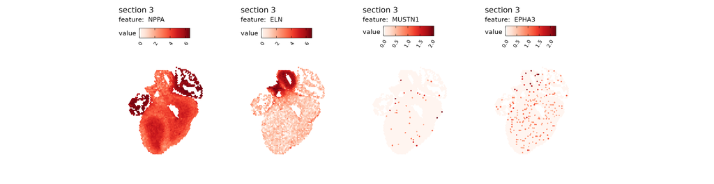

**Left two:** highest spatial autocorrelation — coherent domains.

**Right two:** lowest — scattered, despite all four being in the top 500 *variable* genes.

# Wrap-up

## What we did

- Loaded Visium data and plotted genes on tissue
- Made and justified filtering decisions
- Normalized, scaled, reduced, clustered
- Mapped clusters back onto anatomy and named them
- Compared against a published atlas
- Scaled to three sections and confronted batch effects
- Asked a temporal question, and found its limits
- Used the coordinates as actual spatial information

## What we skipped

- **Deconvolution** — mapping single-cell states into spots
- **Niche analysis** — which structures neighbour which
- **Spatially aware clustering** — BANKSY and similar
- **Cell–cell interaction** inference
- **Pathway** and pseudotime analysis

All of these are in the paper, and the atlas viewer lets you explore the results without writing any code.

## Where to go next

- [semla documentation](https://spatial-research.github.io/semla/index.html)
- [Seurat spatial vignette](https://satijalab.org/seurat/articles/spatial_vignette)
- [Seurat guided clustering](https://satijalab.org/seurat/archive/v3.0/pbmc3k_tutorial.html)
- [Seurat integration & label transfer](https://satijalab.org/seurat/archive/v3.2/integration.html)
- [Single-cell QC & Clustering](https://rnabio.org/module-08-scrna/0008/02/01/QA_clustering/)
- [NBIS detailed slides](https://nbisweden.github.io/workshop-scRNAseq/home_contents.html)
- [Deconvolution with Stereoscope](https://www.nature.com/articles/s42003-020-01247-y)
- [Spatially aware clustering with BANKSY](https://github.com/prabhakarlab/Banksy)
- [Spatial interactions with SpatialDM](https://github.com/StatBiomed/SpatialDM) . . .

**The atlas** → https://hdcaheart.serve.scilifelab.se

**The code** → https://github.com/rmauron/HDCA_heart_dev

## The one thing to take away

Every step was a choice

Which genes to remove. Whether to filter spots. How many PCs. What resolution. Whether to correct for batch, and how hard.

The software will never refuse. **You** have to be able to say why.

## Thank you

Questions welcome — today, and afterwards.

Raphaël Mauron